# R Notebook

## ———————————————————————————————————————————

## ———————————————————————————————————————————

## ———————————————————————————————————————————

Apartado C Ley de Benford. e ha mandado una factura a la empresa Xdata que parece ser falsa. Esta factura tiene muchos números que no parecen generados de modo natural. Comprobamos si efectivamente la factura está generada artificalmente basándonos en la Ley de Benford https://es.wikipedia.org/wiki/Ley_de_Benford

Esta ley trata sobre la distribución de los primeros dígitos en: - facturas - artículos en revistas - direcciones de calles - precios de acciones - número de habitantes - tasas de mortalidad - longitud de los ríos - Física - constantes matemáticas - números primos

La ley Benford establece que la distribución natural de los primeros dígitos es

0.301,0.176,0.125,0.097,0.079,0.067,0.058,0.051,0.046. Esto quiere decir que el uno suele ser el primer dígito el 30% de las veces, el dos 0.176… y así consecutivamente.

Las frecuencias de los primeros dígitos de las facturas de la empresa resultan ser

7, 13, 12, 9, 9, 13, 11, 10, 16 ¿Son facturas falsas? 1 7 veces, 2 13 veces…

Un video interesante sobre la ley de Bendford -> https://www.youtube.com/watch?v=yyiQ1i3USPo Paquete: https://cran.r-project.org/web/packages/benford.analysis/benford.analysis.pdf

```r
#install.packages("benford.analysis")
library(benford.analysis)
```

```r
frecuencias<-c(7,13,12,9,9,13,11,10,16)
#Ejemplo incluido en el paquete
data(corporate.payment)
head(corporate.payment)
```

|  | VendorNum | Date | InvNum | Amount |
| --- | --- | --- | --- | --- |
| 1 | 2001 | 2010-01-02 | 0496J10 | 36.08 |
| 2 | 2001 | 2010-01-02 | 1726J10 | 77.80 |
| 3 | 2001 | 2010-01-02 | 2104J10 | 34.97 |
| 4 | 2001 | 2010-01-02 | 2445J10 | 59.00 |
| 5 | 2001 | 2010-01-02 | 3281J10 | 59.56 |
| 6 | 2001 | 2010-01-02 | 3822J10 | 50.38 |

Then to validade the data against Benford’s law you simply use the function benford in the appropriate column:

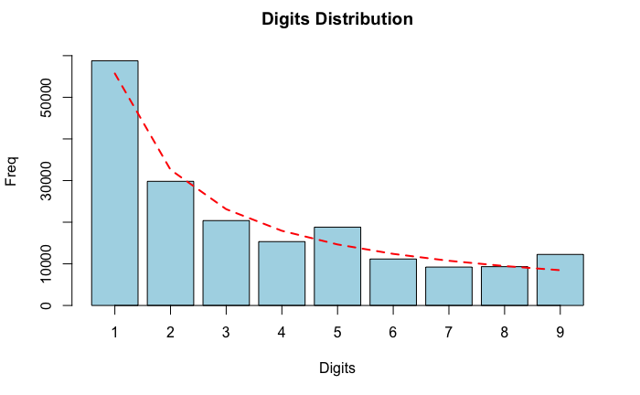

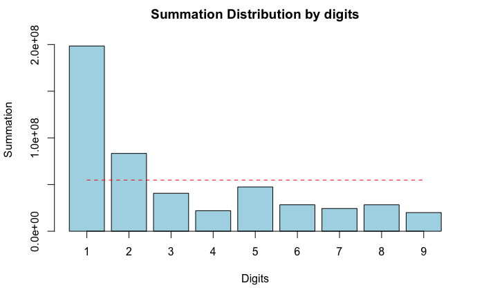

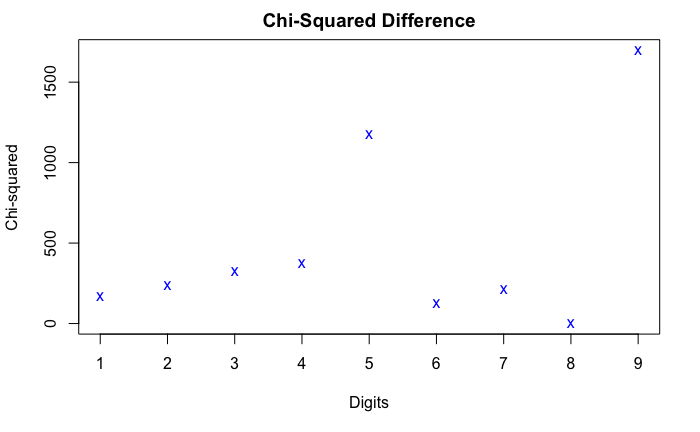

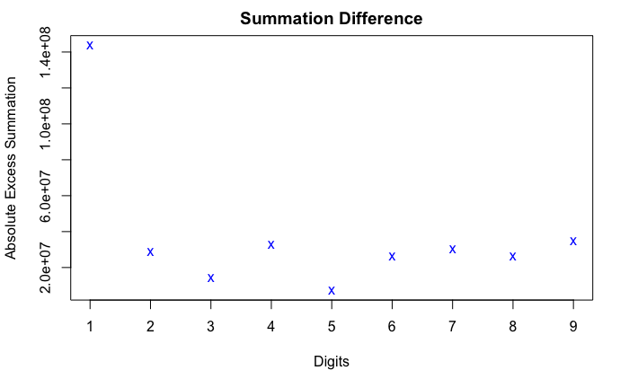

[figure not shown]

```r
bfd.cp <- benford(corporate.payment$Amount,number.of.digits = 1)
plot(bfd.cp, except=c("mantissa", "chi square", "abs diff", "second order"), multiple = F)
```

```r
bfd.cp
```

```
Benford object:

Data: corporate.payment$Amount
Number of observations used = 185083
Number of obs. for second order = 65504
First digits analysed = 1

Mantissa:

   Statistic  Value
        Mean  0.496
         Var  0.092
 Ex.Kurtosis -1.257
    Skewness -0.002


The 5 largest deviations:

  digits absolute.diff
1      5       4154.90
2      9       3790.07
3      1       3058.47
4      2       2774.50
5      3       2738.04

Stats:

    Pearson's Chi-squared test

data:  corporate.payment$Amount
X-squared = 4317.3, df = 8, p-value < 2.2e-16


    Mantissa Arc Test

data:  corporate.payment$Amount
L2 = 0.0039958, df = 2, p-value < 2.2e-16

Mean Absolute Deviation: 0.01321141
Distortion Factor: -1.065467

Remember: Real data will never conform perfectly to Benford's Law. You should not focus on p-values!
```

7, 13, 12, 9, 9, 13, 11, 10, 16

```r
#Con el ejemplo del problema
numeros<-c(1,2,3,4,5,6,7,8,9)
frecuencias<-c(7,13,12,9,9,13,11,10,16)
df<- data.frame(numeros,frecuencias)
df <- expand.dft(df, freq="frecuencias")
df
```

| numeros |
| --- |
| 1 |
| 1 |
| 1 |
| 1 |
| 1 |
| 1 |
| 1 |
| 2 |
| 2 |
| 2 |

[output cut: 90 more lines]

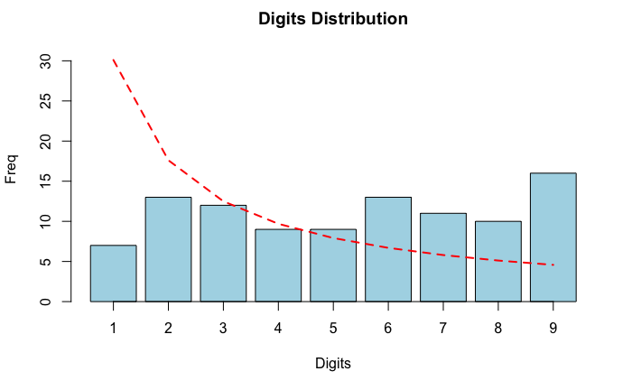

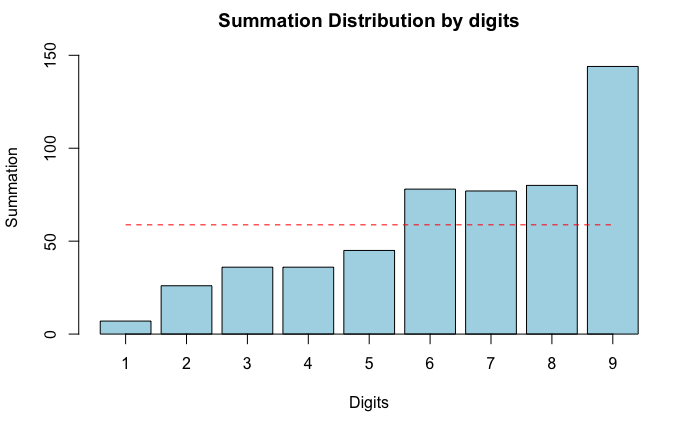

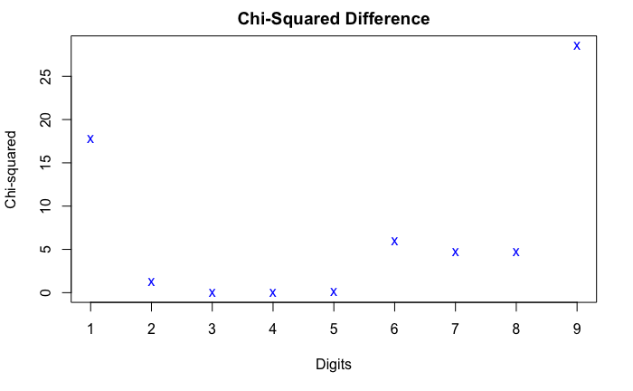

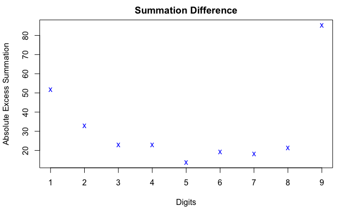

[figure not shown]

```r
bfd.cp <- benford(df$numeros,number.of.digits = 1)
plot(bfd.cp, except=c("mantissa", "chi square", "abs diff", "second order"), multiple = F)
```

Podemos observar que no cumple la ley a simple vista

```r
bfd.cp
```

```
Benford object:

Data: df$numeros
Number of observations used = 100
Number of obs. for second order = 8
First digits analysed = 1

Mantissa:

   Statistic  Value
        Mean  0.651
         Var  0.078
 Ex.Kurtosis -0.205
    Skewness -0.857


The 5 largest deviations:

  digits absolute.diff
1      1         23.10
2      9         11.42
3      6          6.31
4      7          5.20
5      8          4.88

Stats:

    Pearson's Chi-squared test

data:  df$numeros
X-squared = 62.944, df = 8, p-value = 1.229e-10


    Mantissa Arc Test

data:  df$numeros
L2 = 0.11941, df = 2, p-value = 6.52e-06

Mean Absolute Deviation: 0.06421556
Distortion Factor: NaN

Remember: Real data will never conform perfectly to Benford's Law. You should not focus on p-values!
```

Otra forma es comparar las dos muestras con un Test Chi Cuadrado de Bondad.

```r
prob <- c(0.301,0.176,0.125,0.097,0.079,0.067,0.058,0.051,0.046)
freqs <- c(7, 13, 12,  9,  9, 13, 11, 10, 16)
chisq.test(freqs,p=prob)
```

```
Chi-squared approximation may be incorrect
```

```
    Chi-squared test for given probabilities

data:  freqs
X-squared = 62.7, df = 8, p-value = 1.373e-10
```

No se pueden considerar iguales las distribuciones, por tanto las facturas no cumplen la Ley Benford y son potencialmente falsas.

## ———————————————————————————————————————————

## ———————————————————————————————————————————

## ———————————————————————————————————————————

Apartado D Carga el dataset data(“PlantGrowth”) PlantGrowth

```r
rm(list=ls())
data("PlantGrowth")
PlantGrowth
```

| weight | group |
| --- | --- |
| 4.17 | ctrl |
| 5.58 | ctrl |
| 5.18 | ctrl |
| 6.11 | ctrl |
| 4.50 | ctrl |
| 4.61 | ctrl |
| 5.17 | ctrl |
| 4.53 | ctrl |
| 5.33 | ctrl |
| 5.14 | ctrl |

[output cut: 20 more lines]

¿ Se puede considerar que con los tres tratamientos las plantas tienen el mismo crecimiento? Haz un análisis exploratorio Comprueba las asunciones del modelo Realiza el one-way ANOVA ¿ Qué conclusiones se pueden inferir de esta muestra?

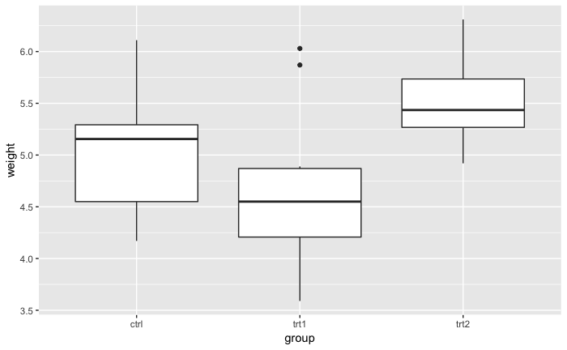

```r
p <- ggplot(PlantGrowth, aes(group, weight))
p + geom_boxplot(na.rm=TRUE)
```

Vemos medias bastante diferentes. La desviación parece similar.

[figure not shown]

```r
ggplot(PlantGrowth, aes(x=group, fill=weight)) + geom_density(alpha=.3)
```

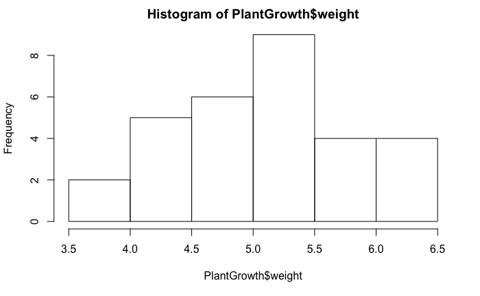

```r
hist(PlantGrowth$weight)
```

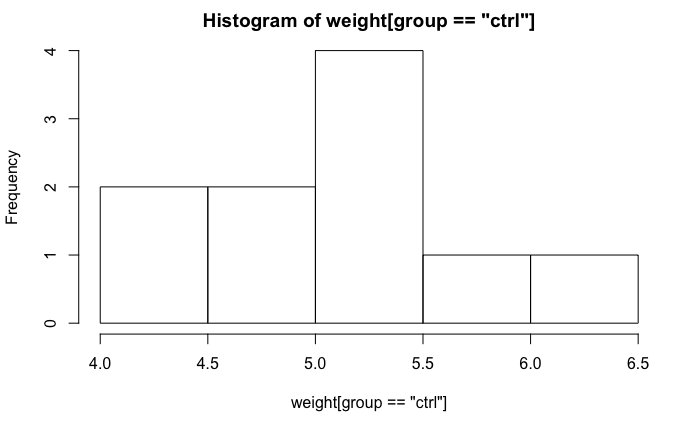

```r
attach(PlantGrowth)
hist(weight[group=="ctrl"])
```

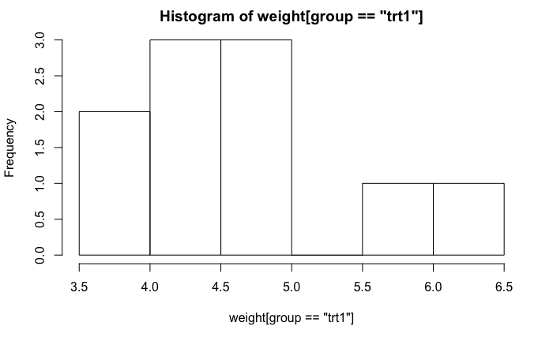

```r
hist(weight[group=="trt1"])
```

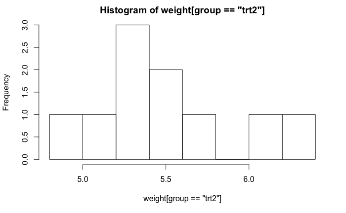

```r
hist(weight[group=="trt2"])
```

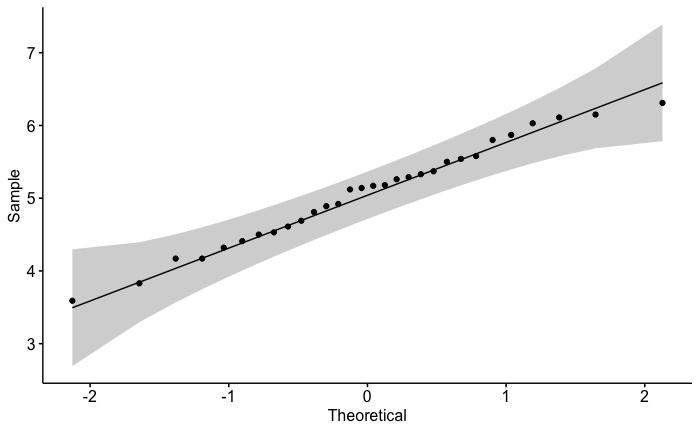

```r
ggqqplot(PlantGrowth$weight)
```

```r
shapiro.test(PlantGrowth$weight)
```

```
    Shapiro-Wilk normality test

data:  PlantGrowth$weight
W = 0.98268, p-value = 0.8915
```

```r
levels(PlantGrowth$group)
```

```
[1] "ctrl" "trt1" "trt2"
```

TEST Anova

```r
 #test asumiendo varianzas distintas concluye que no tienen medias iguales por ser p <0.05
oneway.test(PlantGrowth$weight ~ PlantGrowth$group)
```

```
    One-way analysis of means (not assuming equal variances)

data:  PlantGrowth$weight and PlantGrowth$group
F = 5.181, num df = 2.000, denom df = 17.128, p-value = 0.01739
```